# 6. Nonlinear Regression

Modeling crop response to fertilizer rates

Author

Gustavo Roa

# Nonlinear Regression

Regression models describe the relationship between a response variable and one or more explanatory variables.

A linear regression model can include more than a straight-line relationship. For example, a quadratic regression can describe a curved relationship:

$$y = \beta_0 + \beta_1x + \beta_2x^2 + \varepsilon$$

Although the relationship with $x$ is curved, this is still a linear regression model because the model is linear in its parameters ($\beta_0$, $\beta_1$, and $\beta_2$).

A nonlinear regression model is different because the parameters enter the model in a nonlinear way. These models are useful when the biological or agronomic response cannot be adequately described by a standard linear model.

In agronomy, nonlinear response models are commonly used to describe crop responses to fertilizer rates.

In this section, we will focus on two response models:

- **Linear-plateau (LP):** yield increases linearly with fertilizer rate and then reaches a plateau.
- **Quadratic-plateau (QP):** yield follows a curved quadratic response and then reaches a plateau.

Both models are useful for describing fertilizer response and estimating the rate at which additional fertilizer no longer produces an increase in the modeled response.

# Linear-plateau model

The **linear-plateau (LP)** model assumes that yield increases linearly until a breakpoint and then remains constant.

$$Y =
\begin{cases}
\beta_0 + \beta_1X, & X \leq X_0 \\
Y_0, & X > X_0
\end{cases}$$

where:

- $Y$ is grain yield.
- $X$ is sulfur rate.
- $\beta_0$ is the intercept.
- $\beta_1$ is the slope before the plateau.
- $X_0$ is the breakpoint.
- $Y_0$ is the plateau yield.

The **breakpoint** represents the estimated sulfur rate where the response reaches the plateau.

# Quadratic-plateau model

The **quadratic-plateau (QP)** model allows the response to curve before reaching the plateau.

$$Y =
\begin{cases}
\beta_0 + \beta_1X + \beta_2X^2, & X \leq X_0 \\
Y_0, & X > X_0
\end{cases}$$

where $\beta_2$ controls the curvature of the response.

The QP model can be useful when yield increases rapidly at lower fertilizer rates and the increase becomes smaller as fertilizer rate increases.

# Load the required packages

```r
# Import Excel data
library(readxl)

# Create graphs
library(ggplot2)

# Fit nonlinear models
library(nlraa)
```

# Load the data

We will use the same dataset used in the previous workshop sections.

```r
# Import the workshop dataset
AllData <- read_excel(
  "Data_example.xlsx",
  sheet = "data"
)

# Check the data structure
str(AllData)
```

```
tibble [20 × 11] (S3: tbl_df/tbl/data.frame)
 $ year             : num [1:20] 2022 2022 2022 2022 2022 ...
 $ location         : chr [1:20] "Ashland" "Ashland" "Ashland" "Ashland" ...
 $ block            : num [1:20] 1 1 1 1 1 2 2 2 2 2 ...
 $ S_rate_kg_ha     : num [1:20] 34 11 45 22 0 0 34 22 11 45 ...
 $ grain_yield_Mg_ha: num [1:20] 9.04 10.66 11.25 10.06 7.75 ...
 $ biomass_V6_Mg_ha : num [1:20] 0.39 0.46 0.48 0.38 0.69 0.35 0.49 0.75 0.68 0.59 ...
 $ biomass_R1_Mg_ha : num [1:20] 7.82 8.52 7.6 7.47 10.3 ...
 $ S_conc_V6_pct    : num [1:20] 0.28 0.24 0.29 0.25 0.23 0.25 0.25 0.24 0.24 0.25 ...
 $ N_conc_V6_pct    : num [1:20] 3.86 3.65 3.78 3.67 3.74 3.93 3.8 3.68 3.87 3.66 ...
 $ S_conc_R1_pct    : num [1:20] 0.15 0.13 0.14 0.12 0.13 0.16 0.13 0.13 0.11 0.14 ...
 $ N_conc_R1_pct    : num [1:20] 1.7 1.57 1.7 1.38 1.59 1.81 1.62 1.6 1.41 1.63 ...
```

# Explore the response

Before fitting a nonlinear model, it is useful to look at the relationship between sulfur rate and grain yield.

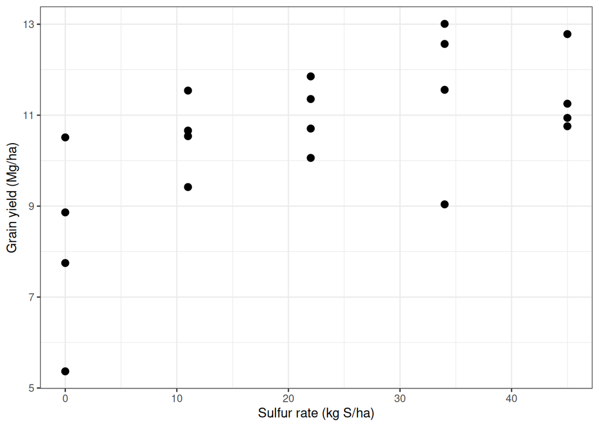

The shape of the relationship provides an initial indication of whether a nonlinear response model may be appropriate.

# Fit the nonlinear models

## Linear-plateau

```r
# Fit the linear-plateau model
model_LP <- nls(
  grain_yield_Mg_ha ~ SSlinp(
    S_rate_kg_ha,
    a,
    b,
    xs
  ),
  data = AllData
)

# Display model results
summary(model_LP)
```

```
Formula: grain_yield_Mg_ha ~ SSlinp(S_rate_kg_ha, a, b, xs)

Parameters:
   Estimate Std. Error t value Pr(>|t|)
a   8.44961    0.63300  13.348 1.94e-10 ***
b   0.13050    0.04457   2.928  0.00939 **
xs 23.28051    6.41271   3.630  0.00207 **
---
Signif. codes:  0 '***' 0.001 '**' 0.01 '*' 0.05 '.' 0.1 ' ' 1

Residual standard error: 1.387 on 17 degrees of freedom

Number of iterations to convergence: 1
Achieved convergence tolerance: 3.894e-08
```

The parameter `xs` is the estimated breakpoint.

## Quadratic-plateau

```r
# Fit the quadratic-plateau model
model_QP <- nls(
  grain_yield_Mg_ha ~ SSquadp3xs(
    S_rate_kg_ha,
    a,
    b,
    xs
  ),
  data = AllData
)

# Display model results
summary(model_QP)
```

```
Formula: grain_yield_Mg_ha ~ SSquadp3xs(S_rate_kg_ha, a, b, xs)

Parameters:
   Estimate Std. Error t value Pr(>|t|)
a    8.1222     0.6727  12.073 9.17e-10 ***
b    0.2941     0.1552   1.895   0.0753 .
xs  21.7652    10.2310   2.127   0.0483 *
---
Signif. codes:  0 '***' 0.001 '**' 0.01 '*' 0.05 '.' 0.1 ' ' 1

Residual standard error: 1.345 on 17 degrees of freedom

Number of iterations to convergence: 17
Achieved convergence tolerance: 1.886e-10
```

The QP model allows the response to curve before reaching the plateau.

# Compare the models

AIC can be used to compare models fitted to the same data.

$$AIC = -2\log(L) + 2K$$

where:

- $L$ is the likelihood of the model.
- $K$ is the number of estimated parameters.

Lower AIC indicates greater support among the models being compared.

```r
# Compare the LP and QP models using AIC
AIC(
  model_LP,
  model_QP
)
```

```
         df      AIC
model_LP  4 74.58831
model_QP  4 73.37775
```

AIC is one tool for model comparison. The shape of the response and biological interpretation should also be considered.

# Plot the fitted models

We can plot both fitted models together with the observed data.

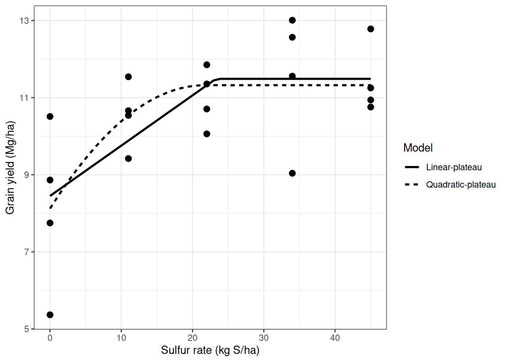

The fitted curves allow us to visually compare how the LP and QP models describe the observed response.

# Model averaging

Sometimes more than one model provides a reasonable description of the data. **Model averaging** is an approach that combines information from multiple candidate models rather than selecting only one.

We will not perform model averaging in this workshop.

[Model averaging for estimation of optimum rate and critical values under model uncertainty](https://hdl.handle.net/2097/47202)

# Exercise

## Exercise 6.1: Fit the linear-plateau model

Fit a linear-plateau model using:

- `grain_yield_Mg_ha` as the response.
- `S_rate_kg_ha` as the explanatory variable.

```r
# Fit the linear-plateau model
model_LP_ex <- nls(
  ____________ ~ SSlinp(
    ____________,
    a,
    b,
    xs
  ),
  data = AllData
)

summary(model_LP_ex)
```

**TipShow solution**

```r
# Fit the linear-plateau model
model_LP_ex <- nls(
  grain_yield_Mg_ha ~ SSlinp(
    S_rate_kg_ha,
    a,
    b,
    xs
  ),
  data = AllData
)

summary(model_LP_ex)
```

```
Formula: grain_yield_Mg_ha ~ SSlinp(S_rate_kg_ha, a, b, xs)

Parameters:
   Estimate Std. Error t value Pr(>|t|)
a   8.44961    0.63300  13.348 1.94e-10 ***
b   0.13050    0.04457   2.928  0.00939 **
xs 23.28051    6.41271   3.630  0.00207 **
---
Signif. codes:  0 '***' 0.001 '**' 0.01 '*' 0.05 '.' 0.1 ' ' 1

Residual standard error: 1.387 on 17 degrees of freedom

Number of iterations to convergence: 1
Achieved convergence tolerance: 3.894e-08
```

## Exercise 6.2: Fit the quadratic-plateau model

Fit a quadratic-plateau model using the same variables.

```r
# Fit the quadratic-plateau model
model_QP_ex <- nls(
  ____________ ~ SSquadp3xs(
    ____________,
    a,
    b,
    xs
  ),
  data = AllData
)

summary(model_QP_ex)
```

**TipShow solution**

```r
# Fit the quadratic-plateau model
model_QP_ex <- nls(
  grain_yield_Mg_ha ~ SSquadp3xs(
    S_rate_kg_ha,
    a,
    b,
    xs
  ),
  data = AllData
)

summary(model_QP_ex)
```

```
Formula: grain_yield_Mg_ha ~ SSquadp3xs(S_rate_kg_ha, a, b, xs)

Parameters:
   Estimate Std. Error t value Pr(>|t|)
a    8.1222     0.6727  12.073 9.17e-10 ***
b    0.2941     0.1552   1.895   0.0753 .
xs  21.7652    10.2310   2.127   0.0483 *
---
Signif. codes:  0 '***' 0.001 '**' 0.01 '*' 0.05 '.' 0.1 ' ' 1

Residual standard error: 1.345 on 17 degrees of freedom

Number of iterations to convergence: 17
Achieved convergence tolerance: 1.886e-10
```

## Exercise 6.3: Compare the models

Use AIC to compare the LP and QP models.

```r
# Compare the models using AIC
AIC(
  ____________,
  ____________
)
```

**TipShow solution**

```r
# Compare the models using AIC
AIC(
  model_LP_ex,
  model_QP_ex
)
```

```
            df      AIC
model_LP_ex  4 74.58831
model_QP_ex  4 73.37775
```

## Exercise 6.4: Interpret the results

Use the model summaries, AIC results, and fitted curves to answer:

1. Which model has the lower AIC?
2. What is the estimated breakpoint for each model?
3. How do the fitted curves differ?
4. Which model would you use to describe the response, and why?

> **Important:** AIC helps compare competing models, but model selection should also consider the shape of the response and its biological meaning.

# Key takeaways

- Nonlinear models describe relationships that are not adequately represented by a straight line.
- LP describes a linear increase followed by a plateau.
- QP allows a curved response before reaching a plateau.
- The breakpoint is an important parameter in fertilizer response models.
- AIC can be used to compare competing models.
- Model selection should consider both statistical evidence and biological meaning.